# Medicare Charges Prediction Pipeline

#### We will be using the [Hospital Charges for Inpatients](https://www.kaggle.com/datasets/speedoheck/inpatient-hospital-charges) dataset to determine if Deep Learning has an advantage at regression modeling. This is a dataset of 163K rows of hospital charge records from 3337 physicians.

#### Our goal is to use the data to predict the average Medicare charges for physicians. Note that the original dataset has been modified to use for regression. The "Average Total Payments" field had a 98% correlation with Medicare charges, as a result it was omitted.

##### Import modules, helpers & models

```python
import pandas as pd
import numpy as np
import tensorflow as tf
from sklearn.linear_model import LinearRegression, Ridge
from sklearn import svm
from sklearn.ensemble import AdaBoostRegressor,  RandomForestRegressor
from sklearn.neural_network import MLPRegressor
from xgboost import XGBRegressor
from lightgbm import LGBMRegressor
from sklearn.model_selection import train_test_split
import warnings
from interpret.glassbox import ExplainableBoostingRegressor

#ignore warnings for a clearer notebook
warnings.simplefilter('ignore')
```

### Physician Level Regression, One Row Per Physician

##### Import providers file

```python
excel_file = pd.ExcelFile('providers.xlsx')
```

df = excel_file.parse('one_row')

```python
df.fillna(0, inplace=True)
```

##### Split into train and test sets

```python
from sklearn.model_selection import train_test_split
```

```python
Xtrain, Xtest, ytrain, ytest = train_test_split(df.drop(columns=['y']), df['y'], test_size=0.2, random_state=201)
```

```python
Xtrain.head()
```

|  | Provider Id | Provider State | 039 - EXTRACRANIAL PROCEDURES W/O CC/MCC | 039 - EXTRACRANIAL PROCEDURES W/O CC/MCC.1 | 057 - DEGENERATIVE NERVOUS SYSTEM DISORDERS W/O MCC | 057 - DEGENERATIVE NERVOUS SYSTEM DISORDERS W/O MCC.1 | 064 - INTRACRANIAL HEMORRHAGE OR CEREBRAL INFARCTION W MCC | 064 - INTRACRANIAL HEMORRHAGE OR CEREBRAL INFARCTION W MCC.1 | 065 - INTRACRANIAL HEMORRHAGE OR CEREBRAL INFARCTION W CC | 065 - INTRACRANIAL HEMORRHAGE OR CEREBRAL INFARCTION W CC.1 | ... | 885 - PSYCHOSES | 885 - PSYCHOSES.1 | 897 - ALCOHOL/DRUG ABUSE OR DEPENDENCE W/O REHABILITATION THERAPY W/O MCC | 897 - ALCOHOL/DRUG ABUSE OR DEPENDENCE W/O REHABILITATION THERAPY W/O MCC.1 | 917 - POISONING & TOXIC EFFECTS OF DRUGS W MCC | 917 - POISONING & TOXIC EFFECTS OF DRUGS W MCC.1 | 918 - POISONING & TOXIC EFFECTS OF DRUGS W/O MCC | 918 - POISONING & TOXIC EFFECTS OF DRUGS W/O MCC.1 | 948 - SIGNS & SYMPTOMS W/O MCC | 948 - SIGNS & SYMPTOMS W/O MCC.1 |
| --- | --- | --- | --- | --- | --- | --- | --- | --- | --- | --- | --- | --- | --- | --- | --- | --- | --- | --- | --- | --- | --- |
| 867 | 110229 | GA | 0.0 | 0.00 | 0.0 | 0.0 | 11.0 | 37099.54 | 29.0 | 26078.44 | ... | 0.0 | 0.00 | 0.0 | 0.00 | 12.0 | 28559.33 | 0.0 | 0.00 | 0.0 | 0.0 |
| 419 | 50526 | CA | 0.0 | 0.00 | 0.0 | 0.0 | 0.0 | 0.00 | 0.0 | 0.00 | ... | 0.0 | 0.00 | 0.0 | 0.00 | 18.0 | 18693.66 | 0.0 | 0.00 | 0.0 | 0.0 |
| 1365 | 200033 | ME | 75.0 | 16001.94 | 15.0 | 14009.4 | 68.0 | 25419.39 | 89.0 | 15614.51 | ... | 13.0 | 18697.38 | 27.0 | 14846.48 | 33.0 | 24973.00 | 29.0 | 12564.37 | 39.0 | 13002.3 |
| 1810 | 290049 | NV | 0.0 | 0.00 | 0.0 | 0.0 | 0.0 | 0.00 | 0.0 | 0.00 | ... | 0.0 | 0.00 | 13.0 | 20895.61 | 0.0 | 0.00 | 0.0 | 0.00 | 0.0 | 0.0 |
| 2308 | 360355 | OH | 0.0 | 0.00 | 0.0 | 0.0 | 0.0 | 0.00 | 0.0 | 0.00 | ... | 0.0 | 0.00 | 0.0 | 0.00 | 0.0 | 0.00 | 0.0 | 0.00 | 0.0 | 0.0 |

5 rows × 202 columns

#### There are over 50 Provider States, creating dummy variables for each would cause the size of the dataset to explode. To keep these features in the dataset without increasing the number of columns we will use mean ordering where we replace the categorical value with the ranking based on the mean of the target variable. In theory this should lead to better results, but since we are using the training set only to perform the ordering it could possibly lead to overfitting.

```python
Xtrain.shape
```

```
(2669, 202)
```

```python
def order_categories(Xtrain, Xtest, ytrain, ytest, categories, target):
    dftrain = pd.concat([Xtrain, ytrain], axis=1).copy()
    dftest = pd.concat([Xtest, ytest], axis=1).copy()
    for col in categories:
        ordered_labels = dftrain.groupby(col).mean().sort_values(by=target).index
        ordinal_label = {k: i for i,k in enumerate(ordered_labels, 0)}
        dftrain[col] = dftrain[col].map(ordinal_label)
        dftest[col] = dftest[col].map(ordinal_label)
    dftrain.drop([target], axis=1, inplace= True)
    dftest.drop([target], axis=1, inplace=True)

    return dftrain, dftest
```

##### Map provider state order rankings to data

```python
Xtrain, Xtest = order_categories(Xtrain, Xtest, ytrain, ytest, ['Provider State'], 'y')
```

```python
from sklearn.preprocessing import MinMaxScaler
min_max_scaler = MinMaxScaler()
```

```python
train_keys = [int(1)]* len(Xtrain)
```

```python
map_dict2 = dict(zip(list(Xtrain['Provider Id'].unique()), train_keys))
```

```python
Xtrain.drop(columns=['Provider Id'], inplace=True)
Xtest.drop(columns=['Provider Id'], inplace=True)
```

```python
Xtrain_cols = Xtrain.columns
```

```python
Xtrain.head()
```

|  | Provider State | 039 - EXTRACRANIAL PROCEDURES W/O CC/MCC | 039 - EXTRACRANIAL PROCEDURES W/O CC/MCC.1 | 057 - DEGENERATIVE NERVOUS SYSTEM DISORDERS W/O MCC | 057 - DEGENERATIVE NERVOUS SYSTEM DISORDERS W/O MCC.1 | 064 - INTRACRANIAL HEMORRHAGE OR CEREBRAL INFARCTION W MCC | 064 - INTRACRANIAL HEMORRHAGE OR CEREBRAL INFARCTION W MCC.1 | 065 - INTRACRANIAL HEMORRHAGE OR CEREBRAL INFARCTION W CC | 065 - INTRACRANIAL HEMORRHAGE OR CEREBRAL INFARCTION W CC.1 | 066 - INTRACRANIAL HEMORRHAGE OR CEREBRAL INFARCTION W/O CC/MCC | ... | 885 - PSYCHOSES | 885 - PSYCHOSES.1 | 897 - ALCOHOL/DRUG ABUSE OR DEPENDENCE W/O REHABILITATION THERAPY W/O MCC | 897 - ALCOHOL/DRUG ABUSE OR DEPENDENCE W/O REHABILITATION THERAPY W/O MCC.1 | 917 - POISONING & TOXIC EFFECTS OF DRUGS W MCC | 917 - POISONING & TOXIC EFFECTS OF DRUGS W MCC.1 | 918 - POISONING & TOXIC EFFECTS OF DRUGS W/O MCC | 918 - POISONING & TOXIC EFFECTS OF DRUGS W/O MCC.1 | 948 - SIGNS & SYMPTOMS W/O MCC | 948 - SIGNS & SYMPTOMS W/O MCC.1 |
| --- | --- | --- | --- | --- | --- | --- | --- | --- | --- | --- | --- | --- | --- | --- | --- | --- | --- | --- | --- | --- | --- |
| 867 | 17 | 0.0 | 0.00 | 0.0 | 0.0 | 11.0 | 37099.54 | 29.0 | 26078.44 | 17.0 | ... | 0.0 | 0.00 | 0.0 | 0.00 | 12.0 | 28559.33 | 0.0 | 0.00 | 0.0 | 0.0 |
| 419 | 35 | 0.0 | 0.00 | 0.0 | 0.0 | 0.0 | 0.00 | 0.0 | 0.00 | 0.0 | ... | 0.0 | 0.00 | 0.0 | 0.00 | 18.0 | 18693.66 | 0.0 | 0.00 | 0.0 | 0.0 |
| 1365 | 10 | 75.0 | 16001.94 | 15.0 | 14009.4 | 68.0 | 25419.39 | 89.0 | 15614.51 | 38.0 | ... | 13.0 | 18697.38 | 27.0 | 14846.48 | 33.0 | 24973.00 | 29.0 | 12564.37 | 39.0 | 13002.3 |
| 1810 | 41 | 0.0 | 0.00 | 0.0 | 0.0 | 0.0 | 0.00 | 0.0 | 0.00 | 0.0 | ... | 0.0 | 0.00 | 13.0 | 20895.61 | 0.0 | 0.00 | 0.0 | 0.00 | 0.0 | 0.0 |
| 2308 | 29 | 0.0 | 0.00 | 0.0 | 0.0 | 0.0 | 0.00 | 0.0 | 0.00 | 0.0 | ... | 0.0 | 0.00 | 0.0 | 0.00 | 0.0 | 0.00 | 0.0 | 0.00 | 0.0 | 0.0 |

5 rows × 201 columns

### Feature Scaling

#### In this example there are 100 DRG codes, and the data is highly sparse since the average is about 50 codes per doctor. As a result we will just use a min-max scaler on all fields (including the Target).

##### Min Max Scaling

```python
Xtrain = min_max_scaler.fit_transform(Xtrain)
Xtest = min_max_scaler.transform(Xtest)
```

```python
Xtrain_cols = list(Xtrain_cols)
```

```python
import numpy as np
ytrain = min_max_scaler.fit_transform(np.array(ytrain).reshape(-1, 1))
ytest = min_max_scaler.transform(np.array(ytest).reshape(-1,1))
```

##### Squeeze array to run through algorithms

```python
ytrain = np.squeeze(ytrain)
ytest = np.squeeze(ytest)
```

### Step 2: Machine Learning Pipeline with GridSearch

#### We will use a Pipeline and GridSearch to find the best performing model through cross-validation. We will compare linear regression, ridge regression, random forests, Adaboost, XGBoost, and a multi-layer perceptron at multiple configurations for each. Once we have the best performing model we'll use the parameters for an output on the test set

```python
from sklearn.pipeline import Pipeline
from sklearn.model_selection import GridSearchCV
```

```python
from pipelinehelper import PipelineHelper
import random
random.seed(101)
```

##### Create regression pipeline

```python
pipe = Pipeline([('regressor', PipelineHelper([('lr', LinearRegression()),
                                               ('rr', Ridge()),
                                              ('svm', svm.SVR()),
                                              ('rf', RandomForestRegressor()),
                                              ('ada', AdaBoostRegressor()),
                                              ('xgb', XGBRegressor()),
                                              ('mlpr', MLPRegressor()),
                                              ('lgbm', LGBMRegressor()),
                                              ('ebm', ExplainableBoostingRegressor(random_state=201, interactions=0))]))])
```

##### Assign hyperparameters for the models

```python
params = {'regressor__selected_model': pipe.named_steps['regressor'].generate({
'rr__alpha': [0.1, 0.3, 0.5, 0.7, 0.9],
'rr__solver': ['auto', 'svd', 'cholesky', 'sparse_cg'],
'rr__tol': [1e-5, 1e-4, 1e-3],
'svm__kernel': ['linear', 'poly', 'rbf'],
'svm__C': [0.1, 0.5, 1.0],
'ada__n_estimators': [10, 100, 200, 500, 1000],
'ada__learning_rate': [0.1, 1.0, 2.0],
'ada__loss': ['linear', 'square'],
'rf__n_estimators': [10, 100, 200, 500, 1000],
'rf__max_depth': [3, 5, 7, 9],
'rf__min_samples_split': [2, 4, 10],
'xgb__booster': ['gbtree', 'gblinear', 'dart'],
'mlpr__hidden_layer_sizes': [ (50, 3), (100,), (100, 3), (100, 5)],
'mlpr__activation': ['relu', 'tanh'],
'mlpr__learning_rate': ['adaptive', 'constant'],
'lgbm__boosting_type': ['gbdt', 'dart'],
'lgbm__learning_rate': [0.1, 0.01, 0.001, 0.05],
'lgbm__n_estimators': [ 200, 500, 1000]
})}
```

##### Perform GridSearch to find the best performing algorithm (5 K-fold cross validation)

```python
grid = GridSearchCV(pipe, params, scoring=['neg_mean_squared_error','r2'], verbose=1, refit=False)
```

```python
grid.fit(Xtrain, ytrain)
```

```
Fitting 5 folds for each of 204 candidates, totalling 1020 fits
```

```
GridSearchCV(estimator=Pipeline(steps=[('regressor',
                                        PipelineHelper(available_models={'ada': AdaBoostRegressor(),
                                                                         'ebm': ExplainableBoostingRegressor(interactions=0,
                                                                                                             random_state=201),
                                                                         'lgbm': LGBMRegressor(),
                                                                         'lr': LinearRegression(),
                                                                         'mlpr': MLPRegressor(),
                                                                         'rf': RandomForestRegressor(),
                                                                         'rr': Ridge(),
                                                                         'svm': SVR(),
                                                                         'xgb': XGBRegressor(base_score=None,
                                                                                             booster=None,...
                                                        {'alpha': 0.5,
                                                         'solver': 'auto',
                                                         'tol': 1e-05}),
                                                       ('rr',
                                                        {'alpha': 0.5,
                                                         'solver': 'auto',
                                                         'tol': 0.0001}),
                                                       ('rr',
                                                        {'alpha': 0.5,
                                                         'solver': 'auto',
                                                         'tol': 0.001}),
                                                       ('rr',
                                                        {'alpha': 0.5,
                                                         'solver': 'svd',
                                                         'tol': 1e-05}),
                                                       ('rr',
                                                        {'alpha': 0.5,
                                                         'solver': 'svd',
                                                         'tol': 0.0001}),
                                                       ('rr',
                                                        {'alpha': 0.5,
                                                         'solver': 'svd',
                                                         'tol': 0.001}), ...]},
             refit=False, scoring=['neg_mean_squared_error', 'r2'], verbose=1)
```

### Step 3: Sklearn/EBM/XGB/LGBM Results

##### Order the models by average performance

```python
model_results = zip(grid.cv_results_['param_regressor__selected_model'], grid.cv_results_['rank_test_neg_mean_squared_error'], grid.cv_results_['mean_test_neg_mean_squared_error'], grid.cv_results_['mean_test_r2'], grid.cv_results_['mean_fit_time'] )
```

```python
model_results = list(model_results)
```

```python
model_results.sort(key=lambda y: y[1])
```

```python
model_results_df = pd.DataFrame(model_results)
model_results_df.columns = ['Model/Params', 'Rank', 'Mean Neg Sq Error', 'Mean R2','Mean Test Time']
```

```python
pd.set_option('display.max_rows', None)
pd.set_option('display.max_colwidth', None)
```

#### Model Performance Ranking

```python
model_results_df.set_index('Rank')
```

| Rank | Model/Params | Mean Neg Sq Error | Mean R2 | Mean Test Time |
| --- | --- | --- | --- | --- |
| 1 | (lgbm, {'boosting_type': 'dart', 'learning_rate': 0.1, 'n_estimators': 1000}) | -0.001751 | 0.936393 | 3.663838 |
| 2 | (lgbm, {'boosting_type': 'dart', 'learning_rate': 0.1, 'n_estimators': 500}) | -0.001762 | 0.935937 | 1.584579 |
| 3 | (lgbm, {'boosting_type': 'gbdt', 'learning_rate': 0.01, 'n_estimators': 1000}) | -0.001798 | 0.934612 | 2.198337 |
| 4 | (lgbm, {'boosting_type': 'gbdt', 'learning_rate': 0.05, 'n_estimators': 500}) | -0.001806 | 0.934294 | 0.892458 |
| 5 | (lgbm, {'boosting_type': 'gbdt', 'learning_rate': 0.05, 'n_estimators': 1000}) | -0.001809 | 0.934190 | 2.021209 |
| 6 | (lgbm, {'boosting_type': 'gbdt', 'learning_rate': 0.05, 'n_estimators': 200}) | -0.001826 | 0.933576 | 0.382790 |
| 7 | (lgbm, {'boosting_type': 'dart', 'learning_rate': 0.05, 'n_estimators': 1000}) | -0.001855 | 0.932560 | 3.641796 |
| 8 | (lgbm, {'boosting_type': 'gbdt', 'learning_rate': 0.1, 'n_estimators': 200}) | -0.001878 | 0.931664 | 0.384824 |
| 9 | (lgbm, {'boosting_type': 'gbdt', 'learning_rate': 0.1, 'n_estimators': 500}) | -0.001878 | 0.931669 | 0.881403 |
| 10 | (lgbm, {'boosting_type': 'gbdt', 'learning_rate': 0.1, 'n_estimators': 1000}) | -0.001881 | 0.931568 | 1.849991 |
| 11 | (lgbm, {'boosting_type': 'gbdt', 'learning_rate': 0.01, 'n_estimators': 500}) | -0.001891 | 0.931248 | 1.194506 |
| 12 | (lgbm, {'boosting_type': 'dart', 'learning_rate': 0.05, 'n_estimators': 500}) | -0.001921 | 0.930160 | 1.469827 |
| 13 | (lgbm, {'boosting_type': 'dart', 'learning_rate': 0.1, 'n_estimators': 200}) | -0.002049 | 0.925416 | 0.486681 |
| 14 | (ebm, {}) | -0.002205 | 0.920029 | 4.533783 |
| 15 | (xgb, {'booster': 'dart'}) | -0.002413 | 0.912012 | 1.525933 |
| 16 | (xgb, {'booster': 'gbtree'}) | -0.002413 | 0.912012 | 0.479337 |
| 17 | (rf, {'max_depth': 9, 'min_samples_split': 4, 'n_estimators': 1000}) | -0.002450 | 0.910919 | 48.980381 |
| 18 | (rf, {'max_depth': 9, 'min_samples_split': 4, 'n_estimators': 500}) | -0.002456 | 0.910682 | 23.956596 |
| 19 | (rf, {'max_depth': 9, 'min_samples_split': 2, 'n_estimators': 200}) | -0.002456 | 0.910696 | 9.995743 |
| 20 | (rf, {'max_depth': 9, 'min_samples_split': 2, 'n_estimators': 1000}) | -0.002459 | 0.910606 | 48.337807 |
| 21 | (rf, {'max_depth': 9, 'min_samples_split': 2, 'n_estimators': 500}) | -0.002469 | 0.910234 | 24.815197 |
| 22 | (rf, {'max_depth': 9, 'min_samples_split': 4, 'n_estimators': 200}) | -0.002471 | 0.910176 | 9.631199 |
| 23 | (rf, {'max_depth': 9, 'min_samples_split': 10, 'n_estimators': 1000}) | -0.002472 | 0.910148 | 45.479446 |
| 24 | (rf, {'max_depth': 9, 'min_samples_split': 10, 'n_estimators': 100}) | -0.002480 | 0.909789 | 4.623404 |
| 25 | (mlpr, {'activation': 'relu', 'hidden_layer_sizes': (100,), 'learning_rate': 'constant'}) | -0.002480 | 0.909552 | 0.163273 |
| 26 | (rf, {'max_depth': 9, 'min_samples_split': 10, 'n_estimators': 200}) | -0.002493 | 0.909353 | 9.176761 |
| 27 | (rf, {'max_depth': 9, 'min_samples_split': 10, 'n_estimators': 500}) | -0.002493 | 0.909389 | 22.754321 |
| 28 | (rf, {'max_depth': 9, 'min_samples_split': 2, 'n_estimators': 100}) | -0.002504 | 0.908945 | 4.991792 |
| 29 | (rf, {'max_depth': 9, 'min_samples_split': 4, 'n_estimators': 100}) | -0.002524 | 0.908290 | 4.903875 |
| 30 | (mlpr, {'activation': 'tanh', 'hidden_layer_sizes': (100,), 'learning_rate': 'constant'}) | -0.002574 | 0.905946 | 0.184820 |

[output cut: 174 more lines]

### Results from Best Performer (Light Gradient Boosting)

#### Light GBM performed best on the training data, in fact variations of LGBM took the top 13 spots, Explainable Boosting with no grid came in 14th place, followed by two XGBoost variations. Light Gradient Boosting (LightGBM) is purported to be an improvement on XGBoost. It reduces memory storage and is faster. It can also handle large scale data. "It uses two novel techniques: Gradient-based One Side Sampling and Exclusive Feature Bundling (EFB) which fulfills the limitations of histogram-based algorithm that is primarily used in all GBDT (Gradient Boosting Decision Tree) frameworks. The two techniques of GOSS and EFB described below form the characteristics of LightGBM Algorithm. They comprise together to make the model work efficiently and provide it a cutting edge over other GBDT frameworks" https://www.geeksforgeeks.org/lightgbm-light-gradient-boosting-machine/ Essentially the boosting is done on a leaf level and features are binned together. It also bundles mutually exclusive features, from one round to the next it takes a sample of the worst performing examples (highest gradient/error) and trains an updated model based on these examples.

```python
from IPython import display
display.Image("https://image.slidesharecdn.com/xgboostandlightgbm-180201121028/95/xgboost-lightgbm-21-638.jpg?cb=1517487076")
```

[output not shown]

```python
lgbm = LGBMRegressor(booster='dart', learning_rate=0.1, n_estimators=1000)
```

```python
model = lgbm.fit(Xtrain, ytrain)
```

```
[LightGBM] [Warning] Unknown parameter: booster
```

```python
y_test_pred = lgbm.predict(Xtest)
y_train_pred = lgbm.predict(Xtrain)
```

```python
from sklearn.metrics import r2_score, mean_squared_error
```

```python
print('The mean squared error of the model on the training set is: ', mean_squared_error(ytrain, y_train_pred))
print('The mean squared error of the model on the test set is: ', mean_squared_error(ytest, y_test_pred))
```

```
The mean squared error of the model on the training set is:  5.7540408211439066e-08
The mean squared error of the model on the test set is:  0.0014179499993923793
```

```python
print('The RSquared score on the training set is: ' , r2_score(ytrain, y_train_pred))
print('The RSquared score on the test set is: ' , r2_score(ytest, y_test_pred))
```

```
The RSquared score on the training set is:  0.999997902954061
The RSquared score on the test set is:  0.9457281519110826
```

#### Our model was able to account for 99.9% of the variance on the training set and 94.6% of the variance on the test set.

### Model Explainability/Shapley Values

```python
import shap

explainer = shap.TreeExplainer(model, feature_names = Xtrain_cols)
shap_values = explainer(Xtrain)
```

#### Global Feature Importance

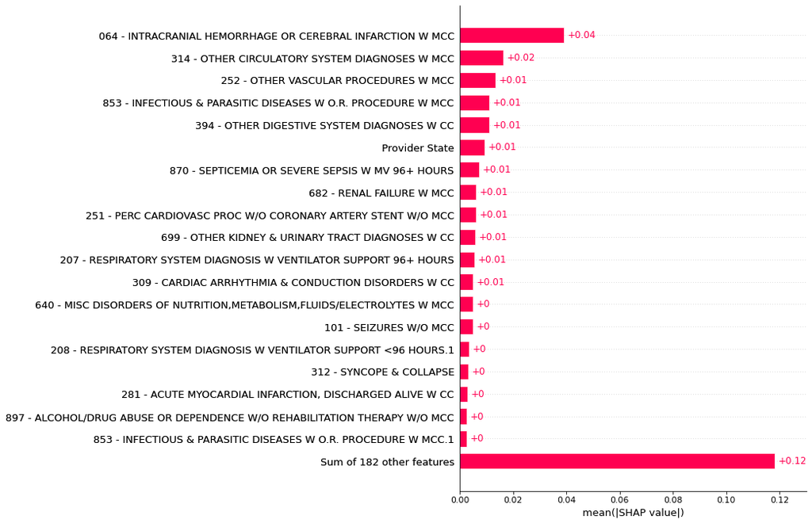

```python
shap.plots.bar(shap_values, max_display=20)
```

#### Explainable Boosting Feature Importance for Comparision

```python
from interpret import show

ebm = ExplainableBoostingRegressor(random_state=201, interactions=0, feature_names = Xtrain_cols)
ebm.fit(Xtrain, ytrain)
ypred_ebm = ebm.predict(Xtest)

ebm_global = ebm.explain_global()
show(ebm_global)
```

[interactive chart not shown]

### Can we best LightGBM with Deep Learning?

### Step 4: Deep Learning in TensorFlow/Keras

```python
from IPython.display import Image
```

We will utilize a sequential model in TensorFlow implemented in Keras. Keras is an API that takes the complexity out of TensorFlow. Keras is the default API sitting on top of TensorFlow 2 and this was the major improvement going from TensorFlow 1 to TensorFlow 2.

#### Artificial Neuron

The artificial neuron is based on the human brain. Each input (feature or prior layer) is multiplied by weights. These weights are summed and a bias is added. This is then summed up and an activation function is applied. The activation function is usually a non-linear function. The non-linear property allows neural networks to take the form of almost any function. This output then goes into another layer or the final output. Each layer can have different activation functions, the final output function can be configured to solve regression or classification problems.

```python
Image(url='https://www.gabormelli.com/RKB/images/thumb/3/31/artificial-neuron-model.png/900px-artificial-neuron-model.png')
```

[figure not shown]

#### Sequential Models

We will use a sequential model. This basically means that we are stacking model layers on top of each other and the input for the next layer is the output of the previous layer. For more complicated models we can use the functional option where we can enable branching and multiple inputs and outputs. Each blue dot is the same as the artificial neuron above. Typically layers are setup with neurons in increments of the powers of 2 (i.e. 32, 64, 128, etc.).

```python
Image(url='https://editor.analyticsvidhya.com/uploads/48655toy%20network.png')
```

[figure not shown]

#### Dense Layers

Dense layers are the basic building block of neural networks in TensorFlow. For each dense layer, you assign a given number of neurons. These layers are "fully connected", every input depends on every previous output. This is similar to regression, but the output can be non-linear, it is of the form sum of (a*x) + b (bias) for the number of input features and then for the output of the prior layer.

```python
Image(url='https://th.bing.com/th/id/R.18a883b3ada38299d328eff2f0c56ad4?rik=Iyg92QtV5tcjIg&pid=ImgRaw&r=0')
```

[figure not shown]

#### Activation Function (ReLu)

The Rectified Linear Activation Function (ReLu) is the activation function we will use for the internal weights. It is a non-linear function that of the form fx = max(0, x). Because it is so simple it is fast to implement. Earlier neural networks also suffered from a "vanishing gradient" problem where deeper networks were harder to train. The ReLu does not suffer from this problem as the gradient is not stuck between 0 and 1. Basically, each neuron in each layer is a math function. The input is a weight and a bias, this is multiplied against the features (in the first layer) or the output of the prior layer. Each variable is multiplied by the weight and then the bias is added. If the collective sum is greater than zero then the value flows through to the next layer. If it is less than zero then the value is zero, and essentially turns off, in which case no information from this neuron flows through to the next layer/output.

```python
Image(url='https://1.bp.blogspot.com/-FXKBzl99Dsw/XcuH4nUoL2I/AAAAAAAAAjk/CCkhAAtSP0Qo1bDTCMFFMnmfqqRJie8qgCEwYBhgL/s1600/relu.png')
```

[figure not shown]

#### The ReLu is the most common activation function, despite the limitation that neurons turn off if the ReLu is zero or less in practice performance does not seem to suffer

#### Regularization (L1L2/Elastic Net)

Deep learning can have several thousand, even millions of parameters, as a result models can overfit. To reduce training bias we will introduce L2 regularization. This is essentially the same regularization concept that we see in linear models. The weights are penalized for being too big, which should reduce bias in the model and lead to better generalization. L1L2 is a combination of ridge and lasso regularization techniques

```python
Image(url='https://corporatefinanceinstitute.com/assets/elastic-net1.png')
```

[figure not shown]

#### Adam Optimization

Adaptive Movement Estimation (Adam) is a smart way of using decay, momentum and different step sizes to try to find the optimal solution for a problem. Adam is considered the "cutting edge" but in different situations one optimization type may outperform the other.

```python
Image(url='https://napsterinblue.github.io/notes/machine_learning/neural_nets/adam_opt/adam_opt_18_0.png')
```

[figure not shown]

```python
input_shp = Xtrain.shape[1]
```

##### Setup Gridsearch criteria for Feedforward network

```python
import tensorflow as tf
from tensorflow.keras.layers import Dense
import tensorflow_addons as tfa
from tensorflow.keras.callbacks import ModelCheckpoint
from tensorflow.keras import Sequential
from tensorflow.keras.layers import Input, Dense, LSTM
```

```python
r2_top = 0
optimal = ''
```

```python
regularizer = [ tf.keras.regularizers.L1L2(1e-5, 1e-4),
                     tf.keras.regularizers.L1L2(1e-4, 1e-4), tf.keras.regularizers.L1L2(1e-5, 1e-5)]
epochs = [10, 20, 30]
learning_rate = [0.1, 0.05, 0.001]
hidden_layers = [32, 64, 128, 256]
batch_size = [16, 32, 64, Xtrain.shape[0]]
bias_initializer = 'zeros'
dropout = [0, 0.25, 0.5, 0.75]
```

```python
#best_mods = []
```

#### Sklearn has a keras wrapper "keras.wrappers.sklearn.KerasClassifier", but I got back nan for all values, so we will do the gridsearch manually

```python
model_num = 0
for reg in range(0,3):
    for lr in range(0, 3):
        for hid in range(0, 4):
            for batch in range(0, 4):
                for epo in range(0,3):
                    checkpoint_path = 'model_checkpoints_reg_dl' +  str(reg) + str(lr) + str(hid) + str(batch) +str(epo)
                    checkpoint = ModelCheckpoint(filepath=checkpoint_path,
                                                frequency='epoch',
                                                save_weights_only=True,
                                                save_best_only=True,
                                                monitor='loss',
                                                verbose=0)
                    tf.keras.backend.clear_session()
                    model = tf.keras.Sequential([
                        Dense(hidden_layers[hid], activation= 'relu', kernel_initializer='glorot_normal', bias_initializer=bias_initializer,kernel_regularizer=regularizer[reg],  input_shape=(input_shp,)),
                        Dense(hidden_layers[hid], activation= 'relu', kernel_initializer='glorot_normal', bias_initializer=bias_initializer,kernel_regularizer=regularizer[reg]),
                        Dense(hidden_layers[hid], activation= 'relu', kernel_initializer='glorot_normal', bias_initializer=bias_initializer,kernel_regularizer=regularizer[reg]),
                        Dense(hidden_layers[hid], activation= 'relu', kernel_initializer='glorot_normal', bias_initializer=bias_initializer,kernel_regularizer=regularizer[reg]),
                        Dense(1)
                    ])
                    model.compile(optimizer='adam', loss='mse', metrics=['mse', tfa.metrics.RSquare()])
                    model.fit(Xtrain, ytrain, epochs = epochs[epo], verbose=0, callbacks=[checkpoint])
                    model_num += 1
                    loss, mse, r2 = model.evaluate(Xtest, ytest)
                    if r2 > r2_top:
                        r2_top = r2
                        optimal = 'New Optimal, model: ', str(model_num), ' hidden layers: ',\
                        hidden_layers[hid], ' activation function: relu', ' regularization: ',  regularizer[reg], \
                        ' learning rate: ', learning_rate[lr], \
                        ' batch size: ', batch_size[batch],\
                        ' optimizer: adam' \
                        ' epochs: ', epochs[epo]
                        print(optimal)
                        print(model.evaluate(Xtest, ytest))
                        print(checkpoint_path)
```

```
('New Optimal, model: ', '1', ' hidden layers: ', 32, ' activation function: relu', ' regularization: ', <keras.regularizers.L1L2 object at 0x00000216018AD280>, ' learning rate: ', 0.1, ' batch size: ', 16, ' optimizer: adam epochs: ', 10)
[0.008607333526015282, 0.0024665065575391054, 0.9055947661399841]
model_checkpoints_reg_dl00000
('New Optimal, model: ', '2', ' hidden layers: ', 32, ' activation function: relu', ' regularization: ', <keras.regularizers.L1L2 object at 0x00000216018AD280>, ' learning rate: ', 0.1, ' batch size: ', 16, ' optimizer: adam epochs: ', 20)
[0.004030883312225342, 0.0013979912037029862, 0.946492075920105]
model_checkpoints_reg_dl00001
('New Optimal, model: ', '54', ' hidden layers: ', 32, ' activation function: relu', ' regularization: ', <keras.regularizers.L1L2 object at 0x00000216018AD280>, ' learning rate: ', 0.05, ' batch size: ', 32, ' optimizer: adam epochs: ', 30)
[0.0031735487282276154, 0.001341306371614337, 0.9486616849899292]
model_checkpoints_reg_dl01012
('New Optimal, model: ', '101', ' hidden layers: ', 32, ' activation function: relu', ' regularization: ', <keras.regularizers.L1L2 object at 0x00000216018AD280>, ' learning rate: ', 0.001, ' batch size: ', 32, ' optimizer: adam epochs: ', 20)
[0.004264838993549347, 0.001328468439169228, 0.9491530656814575]
model_checkpoints_reg_dl02011
('New Optimal, model: ', '297', ' hidden layers: ', 32, ' activation function: relu', ' regularization: ', <keras.regularizers.L1L2 object at 0x00000216018AD310>, ' learning rate: ', 0.1, ' batch size: ', 64, ' optimizer: adam epochs: ', 30)
[0.003972575534135103, 0.0013243717839941382, 0.9493098258972168]
model_checkpoints_reg_dl20022
```

```python
tf.keras.backend.clear_session()

model = tf.keras.Sequential([
    Dense(32, activation= 'relu', kernel_initializer='glorot_normal', bias_initializer=bias_initializer,kernel_regularizer=tf.keras.regularizers.L1L2(1e-5, 1e-4),  input_shape=(input_shp,)),
    Dense(32, activation= 'relu', kernel_initializer='glorot_normal', bias_initializer=bias_initializer,kernel_regularizer=tf.keras.regularizers.L1L2(1e-5, 1e-4)),
    Dense(32, activation= 'relu', kernel_initializer='glorot_normal', bias_initializer=bias_initializer,kernel_regularizer=tf.keras.regularizers.L1L2(1e-5, 1e-4)),
    Dense(32, activation= 'relu', kernel_initializer='glorot_normal', bias_initializer=bias_initializer,kernel_regularizer=tf.keras.regularizers.L1L2(1e-5, 1e-4)),
    Dense(1)
])
model.load_weights('model_checkpoints_reg_dl20022')
model.compile(optimizer=tf.keras.optimizers.Adam(0.1), loss='mse', metrics=['mse', tfa.metrics.RSquare()])
```

```python
loss, mse, r2 = model.evaluate(Xtest, ytest)
```

```python
best_mods.append(['Deep Learning', r2])
```

### Deep Learning Shapley Values

```python
import shap

explainer = shap.KernelExplainer(model, Xtrain[:50], feature_names = Xtrain_cols)
shap_values = explainer.shap_values(Xtrain[:200], nsamples=500)
```

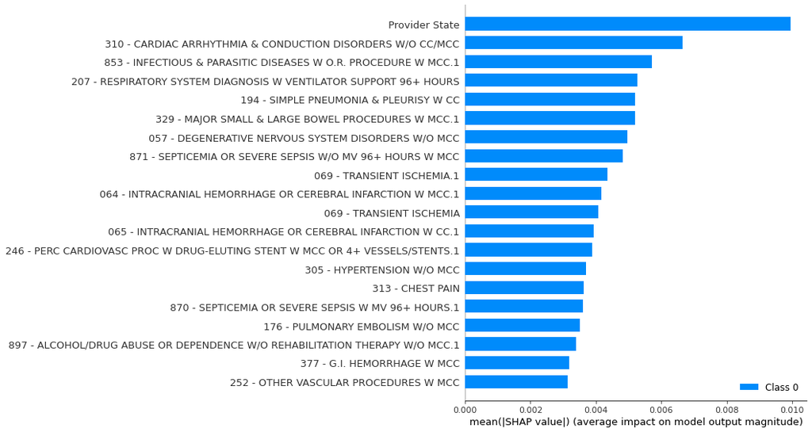

```python
shap.summary_plot(shap_values, plot_type='bar',max_display=20, feature_names = Xtrain_cols)
```

#### Explainable Boosting Feature Importance for Comparision

```python
from interpret import show

ebm = ExplainableBoostingRegressor(random_state=201, interactions=0, feature_names = Xtrain_cols)
ebm.fit(Xtrain, ytrain)
ypred_ebm = ebm.predict(Xtest)

ebm_global = ebm.explain_global()
show(ebm_global)
```

[interactive chart not shown]

### Recurrent Neural Networks (LSTM)

Recurrent neural networks (RNNs) are commonly used for natural language processing tasks such as machine translation and on time-series data such as stocks. Recurrent neural networks are different from feedforward networks in that they have a "feedback loop". The RNN keeps state by basically utilizing a moving average that includes data from the prior iterations.

The RNN that we will utilize is a long-short term RNN (LSTM). On sequential data this is believed to be beneficial for being able to "remember" long term sequences as well as short term sequences.

```python
Image(url='https://cdn-images-1.medium.com/max/1600/1*Niu_c_FhGtLuHjrStkB_4Q.png')
```

[figure not shown]

### Sequential Predictions

With the feeback loop, RNNs have more flexibility than feedforward networks as they can make many to one or many to many predictions. We will use this advantage to try to make predictions on the aggregated sum as well as the individual Medicare charges. In theory the LSTM should be able to "remember" patterns in sequences and possibly lead to better predictions

```python
Image(url='https://discuss.pytorch.org/uploads/default/original/2X/5/598d822d530690ae794fea13c31ce9eeaa6a1020.jpeg')
```

[figure not shown]

```python
r2_top2 = 0
optimal2 = ''
```

### Many to One LSTM

We will first test a many to one LSTM, complexity prevents us from creating a "grid" because the LSTM takes much longer to run than the feedforward network. The entire "sequence" of **{Number of charges (1), Total Charge (1)}, {Number of charges (2), Total Charge (2)},.... {Number of charges (100), Total Charge (100)}... predict {Total Medicare Charge}** will be used to predict the sum of the average Medicare charges

```python
ytrain.shape
```

```
(2669,)
```

```python
new_Xtrain = []
for row_ in Xtrain:
    next_row = []
    for i in range(2,201, 2):
        if row_[i-1] > 0:
            next_row.append([row_[i-1],row_[i]])
        else:
            next_row.append([row_[i-1], row_[i]])
    new_Xtrain.append(next_row)
new_Xtest = []
for row_ in Xtest:
    next_row = []
    for i in range(2,201, 2):
        if row_[i-1] > 0:
            next_row.append([row_[i-1],row_[i]])
        else:
            next_row.append([row_[i-1], row_[i]])
    new_Xtest.append(next_row)
```

```python
new_Xtrain = np.array(new_Xtrain)
new_Xtest = np.array(new_Xtest)
```

```python
checkpoint_path = 'model_checkpoints_lstm_single'
checkpoint2 = ModelCheckpoint(filepath=checkpoint_path,
                            frequency='epoch',
                            save_weights_only=True,
                            save_best_only=True,
                            monitor='val_loss',
                            verbose=0)
tf.keras.backend.clear_session()
model = Sequential([
Input(shape=(100, 2)),
LSTM(50, activation= 'relu', input_shape = (100, 2), return_sequences=True),
LSTM(50, activation= 'relu',  return_sequences=True),
LSTM(50, activation= 'relu', return_sequences=True),
LSTM(50, activation= 'relu', return_sequences=True),
LSTM(50, activation= 'relu', return_sequences=True),
LSTM(50, activation= 'relu'),
Dense(1)
])

model.compile(optimizer='adam', loss='mse', metrics=['mse', tfa.metrics.RSquare()])
model.fit(new_Xtrain, ytrain, epochs = 15, batch_size=32, verbose=1, validation_data=(new_Xtest, ytest), callbacks=[checkpoint2])
model_num += 1
loss, mse, r2 = model.evaluate(new_Xtest, ytest)
```

```python
tf.keras.backend.clear_session()
model = Sequential([
Input(shape=(100, 2)),
LSTM(50, activation= 'relu', input_shape = (100, 2), return_sequences=True),
LSTM(50, activation= 'relu',  return_sequences=True),
LSTM(50, activation= 'relu', return_sequences=True),
LSTM(50, activation= 'relu', return_sequences=True),
LSTM(50, activation= 'relu', return_sequences=True),
LSTM(50, activation= 'relu'),
Dense(1)
])
model.load_weights(checkpoint_path)
model.compile(optimizer='adam', loss='mse', metrics=['mse', tfa.metrics.RSquare()])
```

```python
loss_lstm, mse_lstm, r2_lstm = model.evaluate(new_Xtest, ytest)
```

```python
best_mods.append(['LSTM Many-to-One', r2_lstm])
```

### Many to Many LSTM

We will next test a many to many LSTM, we have to reduce our "grid" because the LSTM takes much longer to run than the feedforward network. Each "sequence" of number of charges and total charges will be used to predict the individual Medicare charge **{Number of charges (1), Total Charge (1)} ... predict {Medicare Charge (1)} , {Number of charges (2), Total Charge (2)} .. predict {Medicare Charge (2)} ... {Number of charges (100), Total Charge (100)} .. predict {Medicare Charge (100)}**

```python
#this file contains the Medicare charge for all 100 DRG definitions
```

```python
y_excel_file = pd.ExcelFile('provider_fee_summary.xlsx')
```

```python
r2_top2 = 0
optimal2 = ''
```

```python
dfy = y_excel_file.parse('Sheet1')
dfy = dfy.fillna(0)
ytrain1, ytest1 = train_test_split(dfy, test_size=0.2, random_state = 201)
ytrain1.drop(columns=['Provider Id'], inplace=True)
ytest1.drop(columns=['Provider Id'], inplace=True)
```

```python
ytrain1.index
```

```
Int64Index([ 867,  419, 1365, 1810, 2308, 1168, 1298, 2350, 2298, 2933,
            ...
             976, 1891, 1033, 3031, 1631,  501,  868, 1377, 1577, 2560],
           dtype='int64', length=2669)
```

```python
ytrain1 = min_max_scaler.fit_transform(np.array(ytrain1))
ytest1 = min_max_scaler.transform(np.array(ytest1))
```

```python
checkpoint_path_lstm = 'model_checkpoints_lstm_100'
checkpoint3 = ModelCheckpoint(filepath=checkpoint_path_lstm,
                            frequency='epoch',
                            save_weights_only=True,
                            save_best_only=True,
                            monitor='val_loss',
                            verbose=0)
tf.keras.backend.clear_session()
model = Sequential([
Input(shape=(100, 2)),
LSTM(50, activation= 'relu', input_shape = (100, 2), return_sequences=True),
LSTM(50, activation= 'relu',  return_sequences=True),
LSTM(50, activation= 'relu', return_sequences=True, dropout=dropout2[drop]),
LSTM(50, activation= 'relu', return_sequences=True),
LSTM(50, activation= 'relu', return_sequences=True),
LSTM(50, activation= 'relu'),
Dense(100)
])


model.compile(optimizer='adam', loss='mse', metrics=['mse', tfa.metrics.RSquare()])
model.fit(new_Xtrain, ytrain1, epochs = 15, verbose=1, validation_data=(new_Xtest, ytest1), callbacks=[checkpoint3])
model_num += 1
loss, mse, r2 = model.evaluate(new_Xtest, ytest1)
```

```python
tf.keras.backend.clear_session()
model = Sequential([
Input(shape=(100, 2)),
LSTM(50, activation= 'relu', input_shape = (100, 2), return_sequences=True),
LSTM(50, activation= 'relu',  return_sequences=True),
LSTM(50, activation= 'relu', return_sequences=True, dropout=dropout2[drop]),
LSTM(50, activation= 'relu', return_sequences=True),
LSTM(50, activation= 'relu', return_sequences=True),
LSTM(50, activation= 'relu'),
Dense(100)
])
model.load_weights(checkpoint_path_lstm)
model.compile(optimizer='adam', loss='mse', metrics=['mse', tfa.metrics.RSquare()])
```

```python
loss_lstm, mse_lstm, r2_lstm = model.evaluate(new_Xtest, ytest1)
```

```python
best_mods.append(['LSTM Many-to-Many', r2_lstm])
```

```python
from sklearn.metrics import r2_score
```

### Step 5: Model Comparison

```python
ebm = ExplainableBoostingRegressor(random_state=201, interactions=0)
ebm.fit(Xtrain, ytrain)
ypred_ebm = ebm.predict(Xtest)
best_mods.append(['Explainable Boosting', r2_score(ytest, ypred_ebm) ])

lgbm = LGBMRegressor(boosting_type='dart', learning_rate=0.1, n_estimators= 1000)
lgbm.fit(Xtrain, ytrain)
ypred_lgbm = lgbm.predict(Xtest)
best_mods.append(['LightGB', r2_score(ytest, ypred_lgbm)])

xgb = XGBRegressor(boosting_type='dart')
xgb.fit(Xtrain, ytrain)
ypred_xgb = xgb.predict(Xtest)
best_mods.append(['XGBoost', r2_score(ytest, ypred_xgb)])
```

[output not shown]

```python
best_mods_df = pd.DataFrame(best_mods)
best_mods_df.columns = ['Model', 'R2']
```

```python
best_mods_df
```

[output not shown]

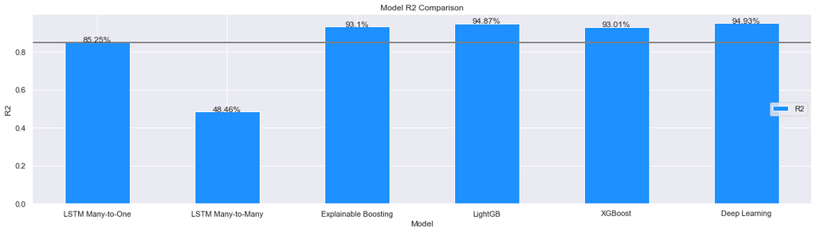

```python
import matplotlib.pyplot as plt
import seaborn as sns


sns.set_theme(style='white')
sns.set(rc={'figure.figsize':(20, 5)})
sns.set(font_scale=1.1)


sns.set(font_scale=1)
ax = best_mods_df.plot.bar(x='Model', y='R2', rot=0,  color='DodgerBlue')
ax.axhline(best_mods_df['R2'].mean(), color='gray', linewidth=2)
ax.legend(loc='right')
ax.title.set_text('Model R2 Comparison')
ax.set( ylabel='R2')
y = best_mods_df['R2']
for i in range(len(y)):
    ax.text(i, y[i], str(int(round(y[i],4)* 10000)/100) + '%', ha='center')
```

### Conclusion

At the expense of a very large grid-search we were able to best all other models with a feedforward deep learning model. Considering that Explainable Boosting had no grid it performed extremely well. Light Gradient Boosting was the best perfomer with minimal tweaking. LSTM models perform poorly, in truth we juxtaposed a sequence with the DRG data, LSTMs are used in many cases in time series analyses, they may not perform well on CMS data without a time component compared to other models.